# Multiple linear regression & least median of squares

Brendan Mapes

9/28/2021

*Multiple linear regression model to predict medv* *(median value of owner-occupied homes in $1000s)* *using the following set of predictors:* *•crim per capita crime rate by town.* *•zn proportion of residential land zoned for lots over 25,000 sq.ft.* *•indus proportion of non-retail business acres per town.* *•nox nitrogen oxides concentration (parts per 10 million).* *•rm average number of rooms per dwelling.* *•age proportion of owner-occupied units built prior to 1940.* *•tax full-value property-tax rate per $10,000.*

```r
lm1 <- lm(boston$medv ~ boston$crim + boston$zn + boston$indus + boston$nox + boston$rm + boston$age + boston$tax, data = boston)

summary(lm1)
```

```
##
## Call:
## lm(formula = boston$medv ~ boston$crim + boston$zn + boston$indus +
##     boston$nox + boston$rm + boston$age + boston$tax, data = boston)
##
## Residuals:
##     Min      1Q  Median      3Q     Max
## -16.625  -3.161  -0.833   2.089  41.042
##
## Coefficients:
##                Estimate Std. Error t value Pr(>|t|)
## (Intercept)  -19.615259   3.221482  -6.089 2.27e-09 ***
## boston$crim   -0.132538   0.038482  -3.444 0.000621 ***
## boston$zn      0.022103   0.014823   1.491 0.136547
## boston$indus  -0.014980   0.072282  -0.207 0.835909
## boston$nox     0.010643   4.230468   0.003 0.997994
## boston$rm      7.606508   0.418424  18.179  < 2e-16 ***
## boston$age    -0.023198   0.014893  -1.558 0.119964
## boston$tax    -0.009006   0.002662  -3.384 0.000772 ***
## ---
## Signif. codes:  0 '***' 0.001 '**' 0.01 '*' 0.05 '.' 0.1 ' ' 1
##
## Residual standard error: 5.989 on 498 degrees of freedom
## Multiple R-squared:  0.5818, Adjusted R-squared:  0.576
## F-statistic: 98.99 on 7 and 498 DF,  p-value: < 2.2e-16
```

*Assessing validity of the underlying assumptions* *•Linearity/functional form* *•Normality* *•Homoscedasticity* *•Uncorrelated error*

The assumption of functional form or linearity refers to the assumption that some linear relationship between the independent and dependent variables in this model exists. If this is not the case, linear regression is not the appropriate modeling method to use. A scatter plot of each independent variable with the dependent variable is a way to check if this assumption holds. Visual inspection of the scatterplots reveals non-linearity. Scatter plots reveal that a linear relationship really only exists with the independent variable *rm*. Therefore, removal of the other variables from the model may be necessary, or another modeling technique should be used. Futher diagnostic tools for this assumption include looking at the R squared value, which is included in the above summary of the model, and plots of residuals versus X. One other way to correct this model may be simple transformations of the numerical values, such as log transformation, to get closer to a linear relationship with some of these variables. OTherwise, these predictors may simply not be the right choices to include in the model.

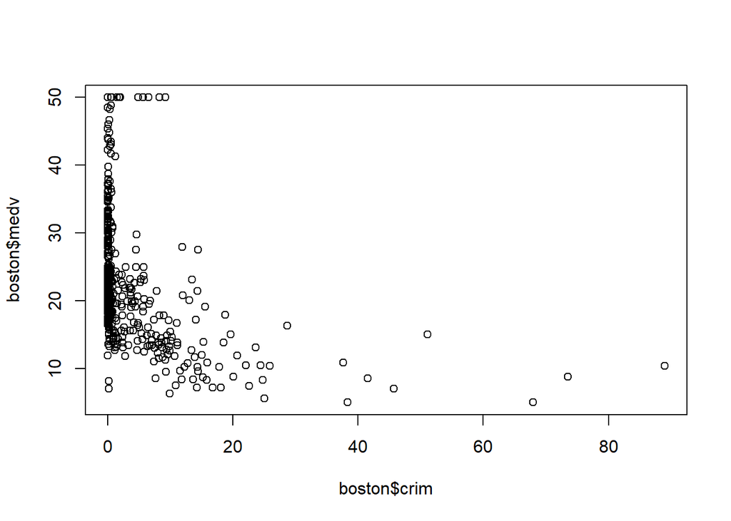

```r
crim <- plot(boston$crim, boston$medv)
```

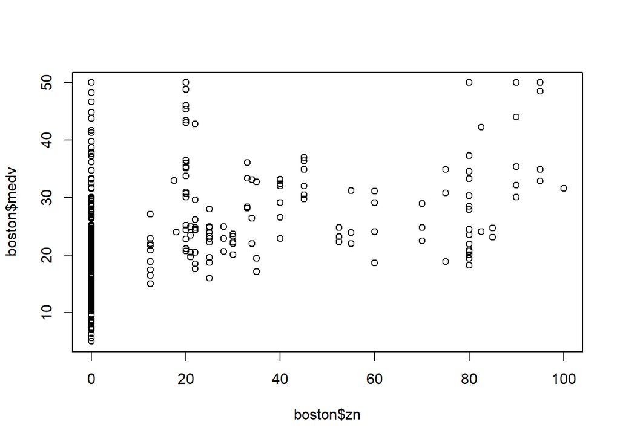

```r
zn <- plot(boston$zn, boston$medv)
```

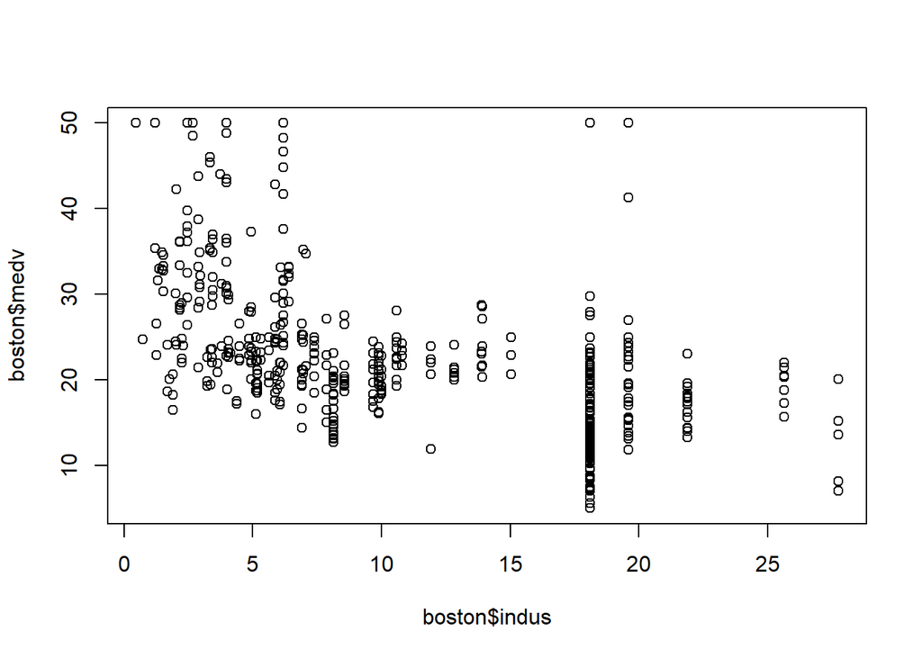

```r
indus <- plot(boston$indus, boston$medv)
```

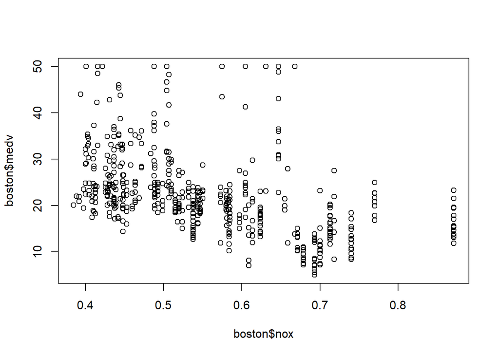

```r
nox <- plot(boston$nox, boston$medv)
```

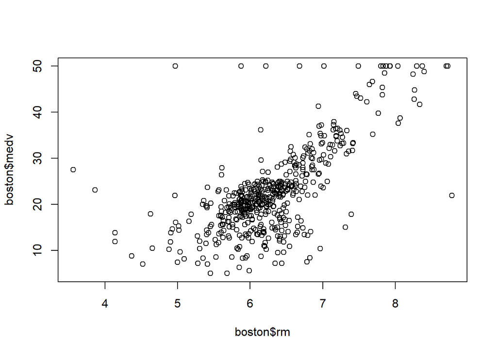

```r
rm <- plot(boston$rm, boston$medv)
```

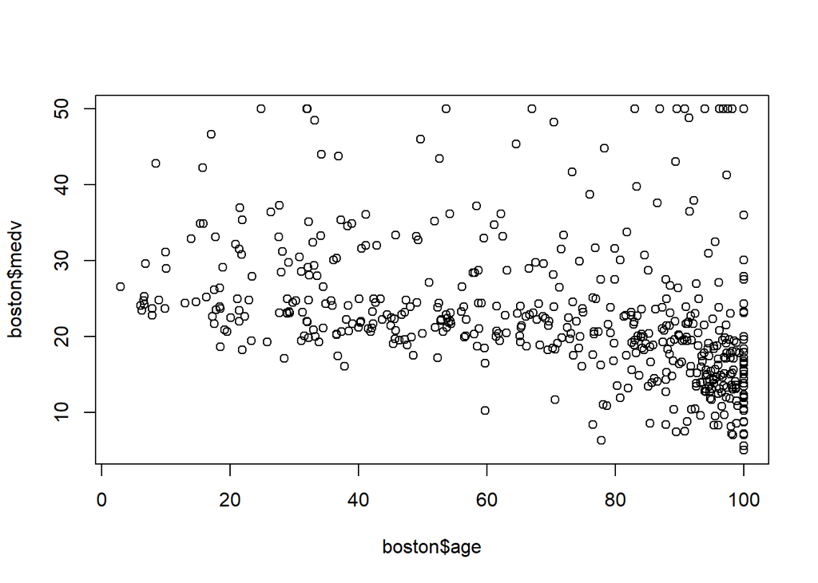

```r
age <- plot(boston$age, boston$medv)
```